# MoveSTIR collapse (study, explorations and thoughts)

2023-05-15

## The universal MoveSTIR framework

1. **Upper right-hand corner**: *non-uniform space use*, *non-stationary time*
- The upper right-hand corner of the box is the most general case where we allow transmission to vary at specific times and specific locations.
1. **Lower right-hand corner**: *non-uniform space use*, *stationary time*
- The lower right-hand corner of the box is where we assume stationarity in movement, but that stationary space use is not necessarily uniform.
1. **Upper left-hand corner**: *uniform space use*, *non-stationary time*
- In the upper left-hand corner, we assume space use is uniform (because, for example, we haven’t observed space use, just contacts) and assume that contact is non-stationary (for example, there are seasonal fluctuations and pulses in contacts)
1. **Lower left-hand corner**: *uniform space use*, *stationary time*
- In the lower left-hand corner, we assume space use is uniform and movement is stationary. Given uncorrelated movements, we get back our standard FOI equation from mean field models.

The goal here is to understand how we infer $E[h_{i \leftarrow j}(t, x)]$ – the expected value of the force of infection $i$ feels from $j$ at time $t$ in location $x$ with area $A_x$. We want also want to understand how we can then infer this quantity from different types of movement and contact data.

## Upper right-hand corner (general case)

We start with the original formulation for the force of infection, and derive it to obtain the *expected* FOI:
$$\begin{aligned}
E[h_{i \leftarrow j}(x,t)] &= E\left[\int_{-\infty}^t \beta \lambda
\delta_i(x, t) \delta_j(x, u) e^{-\nu(t - u)} du\right] \\
&= \int_{-\infty}^t \beta \lambda E[\delta_i(x, t) \delta_j(x, u)]
e^{-\nu(t - u)} du \\
&= \beta \lambda \int_{-\infty}^t \left[p_i(x, t) p_j(x, u) +
Cov(\delta_i(x, t), \delta_j(x, u))\right] e^{-\nu(t - u)} du \text{
(using } E[XY] = E[X]E[Y] + Cov(X, Y))\text{)}\\
&= \beta \lambda \left[\int_{-\infty}^t p_i(x, t) p_j(x, u)
e^{-\nu(t - u)} du + \int_{-\infty}^t Cov(\delta_i(x, t), \delta_j(x,
u)) e^{-\nu(t - u)} du\right] \\
\end{aligned}$$
Scaling by the area of $x$ gives the following general equation for the upper right-hand corner:

$$E[h_{i\leftarrow j}(x,t)]=\frac{\beta'}{A_x} \lambda
\left[\int_{-\infty}^t p_i(x, t) p_j(x, u) e^{-\nu(t - u)} du +
\int_{-\infty}^t Cov(\delta_i(x, t), \delta_j(x, u)) e^{-\nu(t - u)}
du\right]$$

where

- $\beta'$: Acquisition rate (area units per time)
- $\lambda$: Deposition rate ($t^{-1}$)
- $\nu$: Pathogen decay rate in the environment ($t^{-1}$)
- $\delta_i(x, t)$: An indicator random variable specifying whether host $i$ is in area $x$ at time $t$
- $p_i(x, t)$: The marginal probability of host $i$ using habitat area $x$ at time $t$
- $Cov(\delta_i(x, t), \delta_j(x, u))$: The covariance of host $i$ and host $j$ both being in area $x$ at time $t$. Specifically, the spatio-temporal covariance of host $i$ and host $j$ being in “contact” at time $t$

This formulation is slightly different than our previous formulations because $h\_{i \leftarrow j}(t, x)$ is also a *random variable*. This is a more useful formulation when we are thinking about utilization distributions because we want to think about where hosts are going to be with some probability.

## Lower right-hand corner – stationary spatial use

Now, if we assume a stationary distribution, the time indexes on $p_i(x, t)$ and $p_j(x, u)$ are irrelevant—the logic here is that, by definition, the mean of a stationary distribution is independent of time so $p_i(x, t) = p_i(x)$ and $p_j(x, u) = p_j(x)$. Therefore, we can write

$$E[h_{i \leftarrow j}(t, x)] = \beta \lambda \left[p_i(x) p_j(x) (1 /
\nu) + \int_{-\infty}^t Cov(\delta_i(x, t), \delta_j(x, u)) e^{-\nu(t -
u)} du\right]$$

where $\int_{-\infty}^t e^{-\nu(t - u)} du = \frac{1}{\nu}$.

In addition, given stationarity, $E[h_{i \leftarrow j}(t, x)]$ does not depend on time so

$E[h_{i \leftarrow j}(t, x)] = E[h_{i \leftarrow j}(x)]$. Finally, given stationarity, we know that $Cov(\delta_i(x, t), \delta_j(x, u))$ just depends on the the time lag $t - u$ and not specific time stamps, so we are really just focusing on $Cov(\delta_i(x), \delta_j(x) | t - u)$. Thus, we can express the equation as

$$E[h_{i \leftarrow j}(x)] = \beta \lambda \left[p_i(x) p_j(x) (1 / \nu) +
\int_{0}^\infty Cov(\delta_i(x), \delta_j(x) | s) e^{-\nu s} ds\right]$$

where $s = t - u$ (i.e., the lag) and we are integrating over infinite lags.

This equation is pretty cool for a few reasons. First, we see how the UD’s of species $i$ and $j$ affect the average FOI. Second, we see that temporal autocorrelation in movement can increase or decrease the average FOI (some examples below show that this can be really important for estimating pairwise FOI). This makes sense. If you have two individuals moving randomly in an area vs. two individuals that are always together in an area the FOI of the second pair of individuals should be higher.

### Estimating from data

$$Cov(\delta_i(x),\delta_j(x))=\rho[\delta_i(x),\delta_j(x)]\sigma[\delta_i(x)]\sigma[\delta_j(x)]$$

where $\rho(\delta_i(x),\delta_j(x))$ is the correlation between the occurrences of $i$ and $j$ at $x$, and $\sigma(\delta_i(x))$ is the standard deviation of the occurrences of $i$ at $x$. We obtain
$$E[h_{i\leftarrow
j}(x)]=\beta\lambda\left[p_i(x)p_j(x)\frac{1}{\nu}+\int_0^\infty
\rho[\delta_i(x),\delta_j(x)]\sigma[\delta_i(x)]\sigma[\delta_j(x)]
e^{-\nu s}ds\right]$$
If the correlation is constant through time, then we have
$$E[h_{i\leftarrow j}(x)]=\frac{\beta\lambda}{\nu}\left[p_i(x)p_j(x)+
\rho[\delta_i(x),\delta_j(x)]\sigma[\delta_i(x)]\sigma[\delta_j(x)]
\right]$$

We can use this expression that accounts for the entire history of locations of $i$ and $j$ in $x$ if the correlation in movement is constant. In practice we should be integrating across all possible values of $s$, the possible time lags between the presence of $i$ and $j$ at $x$.

```r
# Calculate covariance as the product of correlation and st.dev. for every
# possible value of s
# Possible lag values, from 0 (i and j together at the same
# time), to times-2
lags <- 0:10
# list to populate with covariance results
cov_s <- list()
# matrix of combinations. A t*t matrix of difference in time. This is used to
# find the row-col combinations corresponding to a given lag
lags_mat <- outer(1:points, 1:points, "-")

# For every lag s, find the rows in host 1 and host 2 corresponding to times t
# and t-s, calculate the correlation, st. dev., and their product
for (i in seq_along(lags)) {
  s <- lags[i]
  # find position where those lags occur
  indices <- which(lags_mat==s, arr.ind = T)
  # subset host position matrices with indices
  h1 <- host1[indices[,1],]
  h2 <- host2[indices[,2],]
    # Calculate correlation
    # estimate probs
    # est_probs1 <- apply(host1, 2, mean)
    # est_probs2 <- apply(host2, 2, mean)
    # calculate correlations, st. dev. at every x
    cell_corr <- sapply(1:n, \(x) cor(h1[,x],h2[,x]))
    cell_std1 <- apply(h1, 2, sd)
    cell_std2 <- apply(h2, 2, sd)
    # per-cell covariance
    cov_s[[i]] <- cell_corr*cell_std1*cell_std2
}
# Join together, multiply by exp(-nu*s), sum across values of s for each x
cov_x <- (do.call(rbind,cov_s)*exp(-nu*lags)) |> apply(MARGIN = 2, sum, na.rm = T)
cell_fois <- beta*n/area*lam*(est_probs1*est_probs2/nu+cov_x)
total_foi <- beta/area*lam/nu

cat("Partially correlated movement, full integration:","\nTotal FOI =",total_foi,"\nCell FOI =", sum(cell_fois))
```

```
## Partially correlated movement, full integration:
## Total FOI = 0.1111111
## Cell FOI = 8.914369
```

```r
# we will  create avoidance by establishing the position of i independently, but
# j will avoid locations where i has been in the previous 10 time
# steps.
probs1 <- runif(n)
probs1 <- probs1/sum(probs1)
probs2 <- runif(n)
probs2 <- probs2/sum(probs2)

host1 <- host2 <- matrix(0, nrow = points, ncol = n)
for (i in 1:points) {
  pos1 <- sample(1:n, size = 1, prob = probs1)
  host1[i,pos1] <- 1
}

for (i in 1:points) {
      # get previous 10 locations of host1
  if (i==1) {
    h1locs <- which(host1[i,]==1)
  } else {
    h1locs <- which(host1[i:max(i-10,1),]==1,arr.ind = TRUE)[,2]
  }
# decrease the probability at those locations by 80%
  p2 <- probs2
  p2[h1locs] <- p2[h1locs]*0.2
  pos2 <- sample(1:n, size = 1, prob = p2)
  host2[i,pos2] <- 1
}
# estimate probs
est_probs1 <- apply(host1, 2, mean)
est_probs2 <- apply(host2, 2, mean)
# calculate correlations between hosts at each cell
cell_corr <- sapply(1:n, \(x) cor(host1[,x],host2[,x]))
cell_std1 <- apply(host1, 2, sd)
cell_std2 <- apply(host2, 2, sd)
# per-cell FOI
cell_fois1 <- beta*n/area*lam/nu*(est_probs1*est_probs2+cell_corr*cell_std1*cell_std2)
total_foi1 <- beta/area*lam/nu

lags <- 0:15
# list to populate with covariance results
cov_s <- list()
# matrix of combinations. A t*t matrix of difference in time. This is used to
# find the row-col combinations corresponding to a given lag
lags_mat <- outer(1:points, 1:points, "-")

# For every lag s, find the rows in host 1 and host 2 corresponding to times t
# and t-s, calculate the correlation, st. dev., and their product
for (i in seq_along(lags)) {
  s <- lags[i]
  # find position where those lags occur
  indices <- which(lags_mat==s, arr.ind = T)
  # subset host position matrices with indices
  h1 <- host1[indices[,1],]
  h2 <- host2[indices[,2],]
    # Calculate correlation
    # estimate probs
    # est_probs1 <- apply(host1, 2, mean)
    # est_probs2 <- apply(host2, 2, mean)
    # calculate correlations, st. dev. at every x
    cell_corr <- sapply(1:n, \(x) cor(h1[,x],h2[,x]))
    cell_std1 <- apply(h1, 2, sd)
    cell_std2 <- apply(h2, 2, sd)
    # per-cell covariance
    cov_s[[i]] <- cell_corr*cell_std1*cell_std2
}
# Join together, multiply by exp(-nu*s), sum across values of s for each x
cov_x <- (do.call(rbind,cov_s)*exp(-nu*lags)) |> apply(MARGIN = 2, sum, na.rm = T)

cell_fois2 <- beta*n/area*lam*(est_probs1*est_probs2/nu+cov_x)

cat("Partially correlated movement, full integration:","\nTotal FOI =",total_foi,"\nCell FOI approximation =", sum(cell_fois1, na.rm = T),"\nCell FOI integration =",sum(cell_fois2))
```

```
## Partially correlated movement, full integration:
## Total FOI = 0.1111111
## Cell FOI approximation = 0.0177675
## Cell FOI integration = 0.01341192
```

## Upper left-hand corner – uniform space use

There are instances in which we will not have spatially explicit data. The most evident case is that of proximity loggers, for which you can know *when* and *for how long* two individuals were in contact with each other, but you have no information about where that contact occurred, or whether the location was constant–which will matter for indirect contact. For these cases we need to adapt the general framework so that space use can be implicit. One option is to assume a uniform probability of spatial use. In this case we use a slightly different format for the general equation. We don’t break it into the covariance and the probability of use, but instead write it in terms of conditional probability as follows:

$$\begin{align}
E[h_{i \leftarrow j}(x, t)] &= \beta \lambda \left[\int_{-\infty}^t
E[\delta_i(x, t) \delta_j(x, u)] e^{-\nu(t - u)} du\right] \\
&= \beta \lambda \left[ \int_{-\infty}^t P(i \in x \text{ at }t|j
\in x \text{ at } u) P(j \in x \text{ at } u) e^{-\nu (t-u)}du\right]
\end{align}$$

Here, $P(i \in x \text{ at } t | j \in x \text{ at } u)$ is the probability that host $i$ is in $x$ at time $t$, given host $j$ was in $x$ at a previous time $u$. Since we are assuming uniform space use, the probability of being at any given location $x$ is equal across space, so $P(j \in x \text{ at } u) = P(j\in x) = 1/A_{j,tot}$, where $A_{j,tot}$ is the total area used by $j$. We have then

$$\begin{align}
E[h_{i \leftarrow j}(x, t)] &= \beta \lambda \left[ \int_{-\infty}^t
P(i \in x \text{ at }t|j \in x \text{ at } u) \frac{1}{A_{j,tot}}
e^{-\nu (t-u)}du\right]\\
&=\frac{\beta\lambda}{A_{j,tot}}\int_{-\infty}^t P(i \in x \text{ at
}t|j \in x \text { at } u) e^{-\nu(t-u)}du
\end{align}$$

We can also take $x$ to represent an area of influence, rather than a single point in space. In that case we scale the transmission term by the area of $x$, and obtain
$$E[h_{i \leftarrow j}(x, t)] =
\frac{\beta'\lambda}{A_x}\frac{A_x}{A_{j,tot}}\int_{-\infty}^t P(i
\in x \text{ at } t | j \in x \text{ at } u) e^{-\nu(t - u)} du$$

The key here is that, because we are assuming space is uniform (or we just don’t have information on space use so we are defaulting to an equal probability assumption), any location $x$ with area $A_x$ is just like any other location with area $A_x$. So the location $x$ doesn’t matter, just the area $A_x$. The area $A_x$ can be defined specifically as the area around an individual within which a contact can occur. $P(j \in x \text{ at } u) = \frac{A_x}{A_{j, tot}}$ because it again doesn’t matter what $x$ host $j$ is in because given uniform space use, your probability of being in any area $A_x$ is just $A_x$ over the total area of use. The conditional probability would theoretically capture any potential correlation between visits of $i$ and $j$, potentially linked with attraction or avoidance behaviors.

*Special case: independent movement*

If there is no correlation (i.e. $i$ and $j$ move independently from each other), the probabilities are also independent, so $P(i\in x \text{ at }t | j \in x \text{ at } u)=P(i\in x \text{ at }t)=A_x/A_{i,tot}$, therefore we would have

$$\begin{align}
E[h_{i \leftarrow j}(x, t)] &=
\frac{\beta'}{A_x}\frac{A_x}{A_{j,tot}} \lambda
\int_{-\infty}^t \frac{A_x}{A_{i,tot}} e^{-\nu(t - u)} du \\
&=\frac{\beta'\lambda}{A_x}
\frac{(A_x)^2}{A_{i,tot}A_{j,tot}}\int_{-\infty}^t e^{-\nu(t - u)}
du\\
&=\frac{\beta'\lambda}{\nu} \frac{A_x}{A_{i,tot}A_{j,tot}}
\end{align}$$

This is, the expected FOI from $j$ to $i$, assuming uniform space use and independently moving individuals, is proportional to the ratio of the area of overlap and the product of the two areas of use. In this special case, since the area of overlap is the same, this FOI is symmetrical. This is the same result as the home range overlap metric.

### Estimating from data

1. If movement is not independent, we need to determine the conditional probability $P(i \in x \text{ at }t|j \in x \text{ at }u)$. In the special case of only direct contact, $t=u$, this is simply the probability of $i$ and $j$ being at the same location at the same time. What this gives is a contact vector of 0s and 1s through time, exactly the type of data we would get from proximity loggers.
2. Knowing the lagged versions of $P(i \in x \text{ at } t | j \in x \text{ at } u)$ is impossible from just proximity logger data, but we could start inferring that if we had stationary environmental loggers, or with camera-traps. In this case, you can know the exact time lag between individuals coming to a common location. The cool thing is, then all we have to do is use a logistic regression with a time-varying spline (or something similar) to estimate how contact probability varies through time.
3. We also need $A_{j, tot}$ for one of the hosts. Alternatively, you could just redefine $\beta = \frac{\beta'}{A_{j, tot}} = \frac{\beta'}{A_x} \frac{A_x}{A_{j, tot}}$

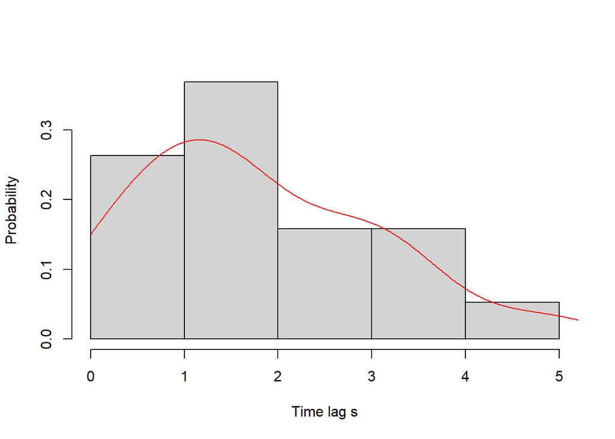

Distribution of waiting times for appearance of i at a given location x following the appearance of j at a previous time - Independent movement

```r
#' Create a detection history for two individuals at a stationary logger.
#' Both appear at constant rates lambda_i = 1/2 and lambda_j = 1/3
lami = 1/2
lamj = 1/3
# The inter-event waiting times are given by the exponential distribution
lag_i = rexp(20, rate = lami)
lag_j = rexp(20, rate = lamj)

# get absolute times
timesi = cumsum(lag_i)
timesj = cumsum(lag_j)

# get the lag between i and j
lags_ij <- outer(timesi, timesj, "-")

# get the minimum positive lag (i.e. the time since the most recent j) for every i
minlag <- apply(lags_ij, 1, \(x) min(x[x>0]))
lag_dens <- density(minlag, from = 0)
hist(minlag, freq = F,xlab = "Time lag s", main = "", ylab = "Probability")
lines(lag_dens$x, lag_dens$y, col="red")
```

```r
with(
  data.frame(beta = 1, lam = 1, mu = 1,
             Ax = 1, Ai = 2, Aj = 3),
  cat("Estimated FOI =", beta*lam/Aj*sum(lag_dens$y*exp(-1*lag_dens$x)))
)
```

```
## Estimated FOI = 5.625573
```

*NOTE: THIS NEEDS CHECKING*

For indirect contact ($t \gt u$), the conditional probability can be interpreted as the probability that $i$ arrives in $x$ ($t-u$) time units after $j$. Put differently, it is the probability that $j$ was in $x$ at a certain time point, and then elsewhere for ($t-u$), and that $i$ was not in $x$ from $u$ to $t$ but arrived there at time $t$. The specific time points $t$ and $u$ are not important, rather it’s the lag $s$ that we care about. Assuming uniform space use, we define:

- $P(i \in x \text{ at }t)=1/A_{i,tot}$ The probability that any individual $i$ is at any given location $x$ at a certain point in time
- $P(i \notin x \text{ at }t)=1-1/A_{i,tot}$ The probability that $i$ is anywhere but $x$ at a certain point in time

Then we have

$$\begin{align}
P(i \in x \text{ at }t|j \in x \text{ at }
t-s)&=\frac{1}{A_{i,tot}}\left(1-\frac{1}{A_{i,tot}}\right)^s\frac{1}{A_{j,tot}}\left(1-\frac{1}{A_{j,tot}}\right)^s\\
&=\frac{1}{A_{i,tot}A_{j,tot}}
\left[\left(1-\frac{1}{A_{i,tot}}\right)\left(
1-\frac{1}{A_{j,tot}}\right)\right]^s\\
\end{align}$$

If again we focus on areas, we have

$$\begin{align}
P(i \in x \text{ at }t|j \in x \text{ at }
t-s)&=\frac{A_x^2}{A_{i,tot}A_{j,tot}}
\left[\left(1-\frac{A_x}{A_{i,tot}}\right)\left(
1-\frac{A_x}{A_{j,tot}}\right)\right]^s\\
\end{align}$$

This is, the conditional probability that $i$ comes to $x$, $s$ time units after $j$, is the square of the area $A_x$ —where contact can occur—divided by the product of both total areas, multiplied by the product of the areas of use excluding area $x$ elevated to the time lag.

Integrating we obtain

$$\begin{align}
E[h_{i \leftarrow
j}(x,t)]&=\frac{\beta'\lambda}{A_x}\frac{A_x}{A_j}\int_0^\infty
\frac{A_x^2}{A_iA_j} \left[\left(1-\frac{A_x}{A_i} \right)
\left(1-\frac{A_x}{A_j} \right)\right]^s e^{-\nu s}ds\\
&=\frac{\beta'\lambda}{A_x}\frac{A_x}{A_j} \frac{A_x^2}{A_iA_j}
\int_0^\infty \left[\left(1-\frac{A_x}{A_i} \right)
\left(1-\frac{A_x}{A_j} \right)\right]^s e^{-\nu s}ds\\
&=C\int_0^\infty (Fe^{-\nu})^sds
\end{align}$$

where $C=\frac{\beta'\lambda A_x^2}{A_iA_j^2}$ and $F=\left[\left(1-\frac{A_x}{A_i} \right) \left(1-\frac{A_x}{A_j} \right)\right]$. The integral is of the form $\int a^u du = a^u/\ln(a)$, so

$$\begin{align}
C\int_0^\infty(Fe^{-\nu})^sds&=C\frac{(Fe^{-\nu})^s}{\ln(Fe^{-\nu})}\\
&=C\frac{(Fe^{-\nu})^s}{\ln(F)-\nu}
\end{align}$$

$0<F<1$ and $0<e^{-\nu}<1$, so evaluating we obtain

$$\begin{align}
\frac{C}{\ln(F)-\nu} (Fe^{-\nu})^s|_0^\infty
&=\frac{C}{\ln(F)-\nu}(-1)\\
&=\frac{C}{\nu-\ln(F)}
\end{align}$$

Replacing $C$ and $F$ gives

$$E[h_{i\leftarrow j}(x,t)]=\frac{\beta'\lambda
A_x^2}{A_iA_j^2}\frac{1}{\nu-\ln\left[\left(1-\frac{A_x}{A_i}\right)\left(1-\frac{A_x}{A_j}\right)\right]}$$

Is this just the same as the special case described above for independent movement, $E[h_{i \leftarrow j}(x,t)]=\frac{\beta'\lambda}{\nu} \frac{A_x}{A_{i,tot}A_{j,tot}}$?

Let’s look at an example. Say we have two individuals with $A_i=2$ and $A_j=3$, and the area of overlap is $A_x=1$.

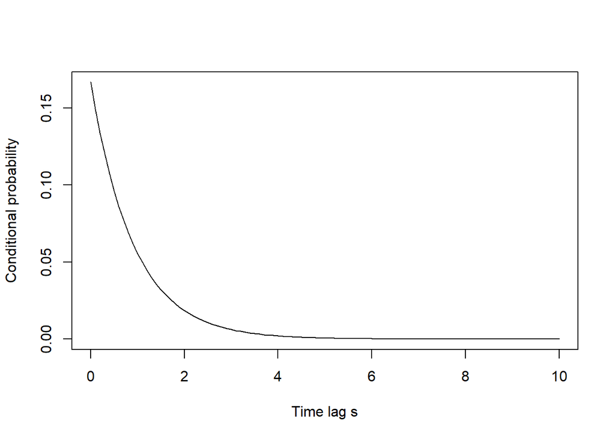

Conditional probability of the time lag between two individuals i and j at the same location x

The conditional probability depends only on the areas of use and of overlap. This probability of $i$ appearing at $x$ decreases exponentially as the time lag following the appearance of $j$ increases. Assuming $\beta=\lambda=\nu=1$, we have

```r
b=1
nu=1
lam=1
Ax=1
Ai=2
Aj=3
Eh1 = b*lam/nu*Ax/(Ai*Aj)
Eh2 = b*lam*Ax^2/(Ai*Aj^2)*1/(nu-log((1-Ax/Ai)*(1-Ax/Aj)))
cat("FOI indep. mov =",Eh1,"\nFOI derived =",Eh2)
```

```
## FOI indep. mov = 0.1666667
## FOI derived = 0.02647252
```

## Lower left-hand corner

The general equation for the lower left-hand corner is

$$\begin{align}
E[h_{i \leftarrow j}(x, t)] &= \frac{\beta'}{A_x} \lambda
\left[\int_{-\infty}^t E[\delta_i(x, t) \delta_j(x, u)] e^{-\nu(t - u)}
du\right] \\
&= \frac{\beta'}{A_x} \lambda \left[\int_{0}^{\infty} P(i \in x
| j \in x, s) \frac{A_x}{A_{j, tot}} e^{-\nu(s)} ds\right]
\end{align}$$

- $P(i \in x | j \in x, s)$: The probability of host $i$ in some location $x$ with area $A_x$ given host $j$ in some location $x$ given a time lag of $s$.

This is similar to the upper left-hand corner, but now time is stationary so we just have one mean contact probability (independent of time) for each lag $s$.

### Estimating from data

- To estimate $P(i \in x | j \in x, s)$ for lag $s = 0$, you just need a vector of 0 or 1 contacts between host $i$ and $j$ and calculate the probability of contact.